# STA 2453 Project 1 - Condos Model

Ruiwen Wang, Charlie Yu, Chenghui Zheng

December 8, 2020

## Goal & Motivation

Our group chose to analyze condo listing data from [Condos.ca](https://condos.ca/).

The goal is to help better understand the properties that affect Toronto condo market for both selling and renting.

We will talk about:

- Data Collection
- Data Preparation
- Exploratory Analysis
- Modeling
- Time Series Analysis

## Data Collection

The website is free to browse as long as you sign up. Also there will be an agent contacting you directly to help you find condos.

Use web scrapping to import data:

- API calls to ‘https://api.condos.ca/v1/’.
- Geography Bound: GTA region
- All historical data from condos.ca (~1.2 million records)
- Active listings as of November 14
- Split the data into Rent and Sale

| offer | n |
| --- | --- |
| Rent | 13213 |
| Sale | 9395 |

*For the next few parts of the presentation, we will focus on processing Rental Data.

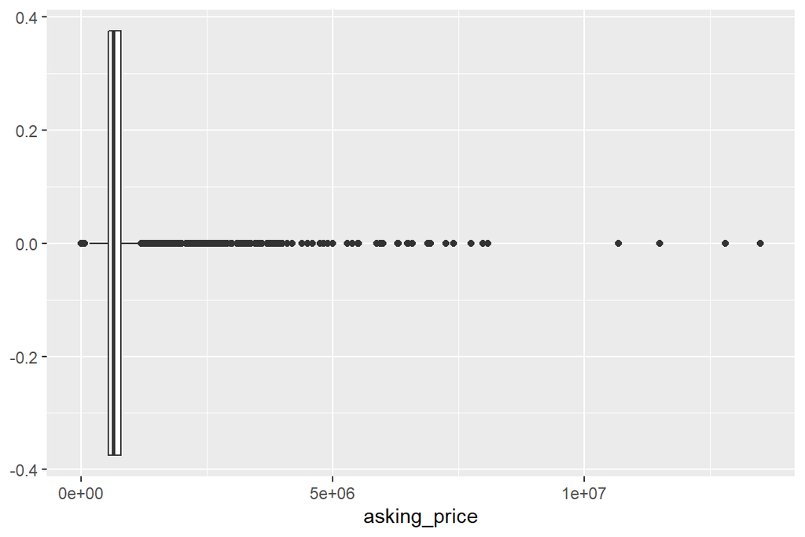

Even the box-plot shows a skewed distribution, we still want to include as most data as we can.

## Data Exclusion

- Only include “Active”
- Remove with rental price < 500 - parking

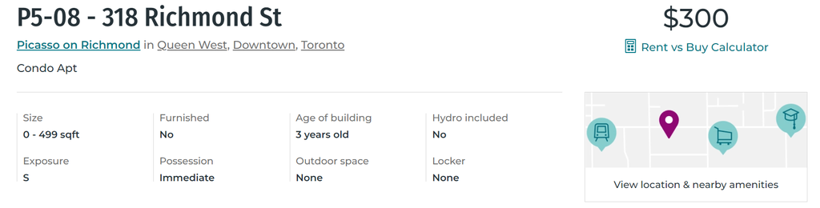

- Overall, 9 records are removed

## Data Preparation - Property Type

- Only leave catogories that have count > 100
- Small classes are merged to “Other”
- Did the same for other categorical variables

| property_type | n |
| --- | --- |
| Co-Op Apt | 40 |
| Co-Ownership Apt | 16 |
| Comm Element Condo | 384 |
| Condo Apt | 11848 |
| Condo Townhouse | 503 |
| Other | 2 |
| Semi-Det Condo | 2 |
| NA | 409 |

| prop_type | n |
| --- | --- |
| Comm Element Condo | 384 |
| Condo Apt | 11848 |
| Condo Townhouse | 503 |
| Other | 469 |

## Data Preparation - Bed Type

- Would like to retain the numerical property of `Bed Type`
- Change “Studio” into `0.5`

| bed_type | n |
| --- | --- |
| 1 | 3738 |
| 1+1 | 3369 |
| 1+2 | 23 |
| 2 | 3306 |
| 2+1 | 1243 |
| 2+2 | 12 |
| 3 | 596 |
| 3+1 | 164 |
| 3+2 | 4 |
| 4 | 50 |
| 4+1 | 12 |
| 4+2 | 1 |
| 5 | 3 |
| 5+1 | 1 |
| 6 | 1 |
| 6+1 | 1 |
| Studio | 680 |

| bed | n |
| --- | --- |
| 0.5 | 680 |
| 1.0 | 3738 |
| 1.5 | 3392 |
| 2.0 | 3306 |
| 2.5 | 1255 |
| 3.0 | 596 |
| 3.5 | 168 |
| 4.0 | 50 |
| 4.5 | 13 |
| 5.0 | 3 |
| 5.5 | 1 |
| 6.0 | 1 |
| 6.5 | 1 |

## Data Preparation - Neighbourhood & Distance from TTC Subway Station

- Include list of Toronto Neighbourhood from [Wikipedia](https://en.wikipedia.org/wiki/List_of_neighbourhoods_in_Toronto) to generalize locality

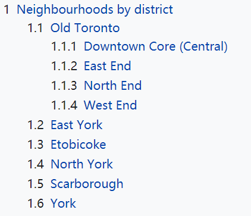

- Include list of TTC subway stations from [Wikipedia](https://en.wikipedia.org/wiki/List_of_Toronto_subway_stations), along with the location data
- Calculate the distance of the condo to the nearest subway station

## Visualization: Active Condos for Rent & TTC Stations

A set of interactive condo maps of Toronto is available on our [github page](https://jiawei-yu-97.github.io/STA2453-proj1-group6/maps.html)

## Exploratory Analysis - Part I

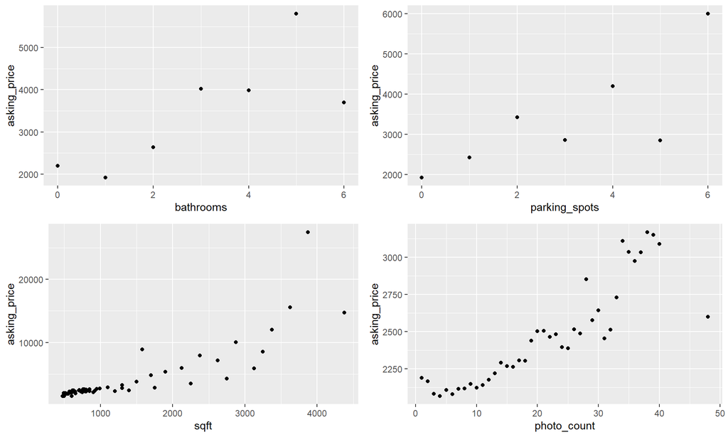

## Exploratory Analysis - Part II

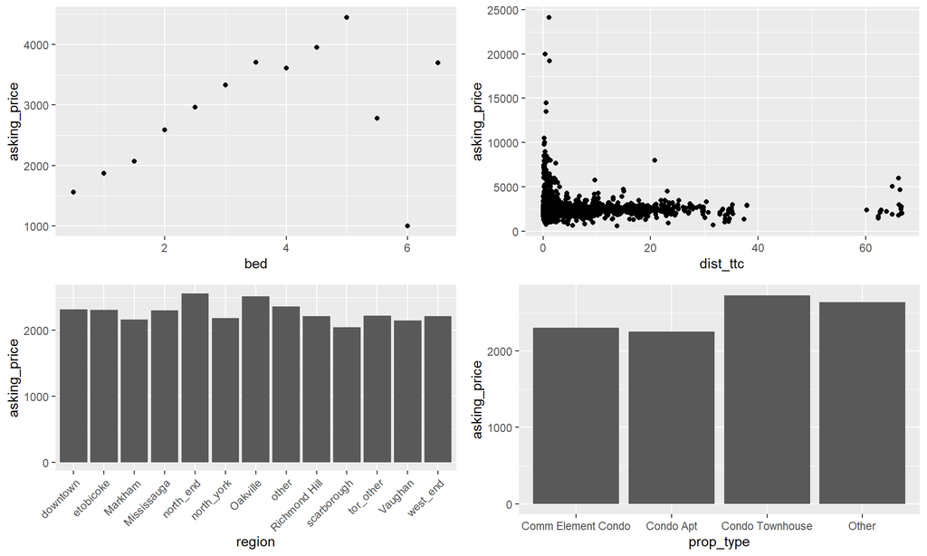

## Modeling of Current House Price (For Rent)

```
##
## Call:
## lm(formula = model, data = df_rent_train)
##
## Residuals:
##     Min      1Q  Median      3Q     Max
## -4453.5  -159.9   -13.7   140.0  5687.0
##
## Coefficients:
##                                      Estimate Std. Error t value Pr(>|t|)
## (Intercept)                          683.5322   164.1125   4.165 3.22e-05 ***
## bathrooms_cap5                      -185.6334    48.6309  -3.817 0.000138 ***
## parking_spots                        302.4504    44.1435   6.852 9.11e-12 ***
## sqft_cap4k                             1.3806     0.2212   6.242 5.03e-10 ***
## photo_cap40                            5.3252     1.0604   5.022 5.47e-07 ***
## prop_typeCondo Apt                  -160.1115   149.4122  -1.072 0.283996
## prop_typeCondo Townhouse             567.2672   186.0165   3.050 0.002315 **
## prop_typeOther                       882.8218   192.3538   4.590 4.65e-06 ***
## bed_cap5                             168.3930    53.9369   3.122 0.001816 **
## regionetobicoke                      759.8282    73.8977  10.282  < 2e-16 ***
## regionMarkham                        866.0628   188.3376   4.598 4.46e-06 ***
## regionMississauga                    838.4516   155.6445   5.387 7.81e-08 ***
## regionnorth_end                      403.7126   122.4379   3.297 0.000990 ***
## regionnorth_york                     848.3374    86.5541   9.801  < 2e-16 ***
## regionOakville                      1136.9628  1103.9131   1.030 0.303135
## regionother                         1040.0576   237.4954   4.379 1.24e-05 ***
## regionRichmond Hill                  809.3298   454.7110   1.780 0.075214 .
## regionscarborough                    779.3403   144.4077   5.397 7.40e-08 ***
## regiontor_other                      809.8336   341.7092   2.370 0.017864 *
## regionVaughan                        843.4483   144.8998   5.821 6.58e-09 ***
## regionwest_end                       173.9649   183.7079   0.947 0.343745
## dist_ttc                             -47.8004    14.0026  -3.414 0.000651 ***
## sqft_cap4k:regionetobicoke            -0.9946     0.1173  -8.481  < 2e-16 ***
## sqft_cap4k:regionMarkham              -2.7910     0.1921 -14.528  < 2e-16 ***
## sqft_cap4k:regionMississauga          -2.6442     0.1636 -16.160  < 2e-16 ***
## sqft_cap4k:regionnorth_end            -0.8429     0.2032  -4.148 3.46e-05 ***
## sqft_cap4k:regionnorth_york           -2.1723     0.1451 -14.974  < 2e-16 ***
## sqft_cap4k:regionOakville             -2.0654     0.3520  -5.868 4.98e-09 ***
## sqft_cap4k:regionother                -2.9570     0.2186 -13.528  < 2e-16 ***
## sqft_cap4k:regionRichmond Hill        -2.4450     0.6937  -3.524 0.000432 ***
```

[output cut: 25 more lines]

```
## bed_cap5:regionnorth_end             156.3123    97.9625   1.596 0.110693
## bed_cap5:regionnorth_york            270.8913    61.6775   4.392 1.17e-05 ***
## bed_cap5:regionOakville              141.7812   232.6295   0.609 0.542265
## bed_cap5:regionother                 453.9155   103.2062   4.398 1.14e-05 ***
## bed_cap5:regionRichmond Hill         290.7746   285.4778   1.019 0.308510
## bed_cap5:regionscarborough           212.5105   109.3819   1.943 0.052145 .
## bed_cap5:regiontor_other             128.9359   231.8537   0.556 0.578185
## bed_cap5:regionVaughan               346.9782    78.4126   4.425 1.00e-05 ***
## bed_cap5:regionwest_end               39.5217    85.9178   0.460 0.645559
## ---
## Signif. codes:  0 '***' 0.001 '**' 0.01 '*' 0.05 '.' 0.1 ' ' 1
##
## Residual standard error: 419.4 on 2576 degrees of freedom
## Multiple R-squared:  0.7808, Adjusted R-squared:  0.7754
## F-statistic: 145.6 on 63 and 2576 DF,  p-value: < 2.2e-16
```

| split | RMSE |
| --- | --- |
| train | 414.3099 |
| test | 532.1638 |

## Time Series: How COVID-19 Affects the Transaction Volume

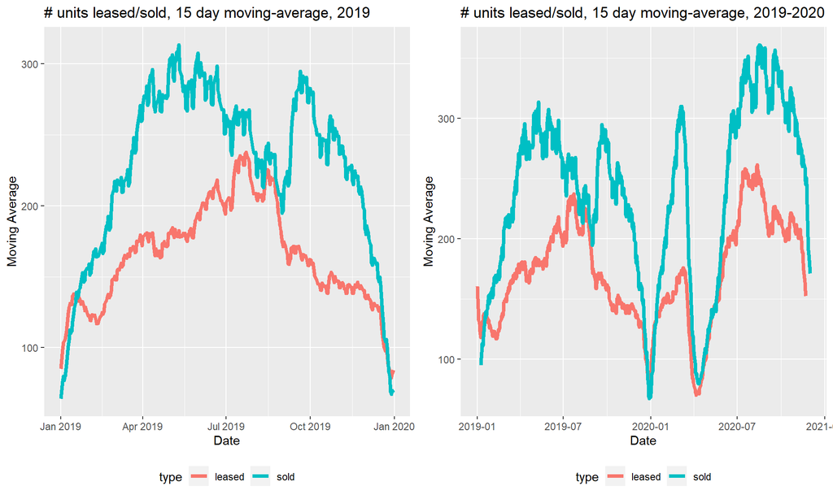

## Time Series: How Prices of condos in Toronto evolved

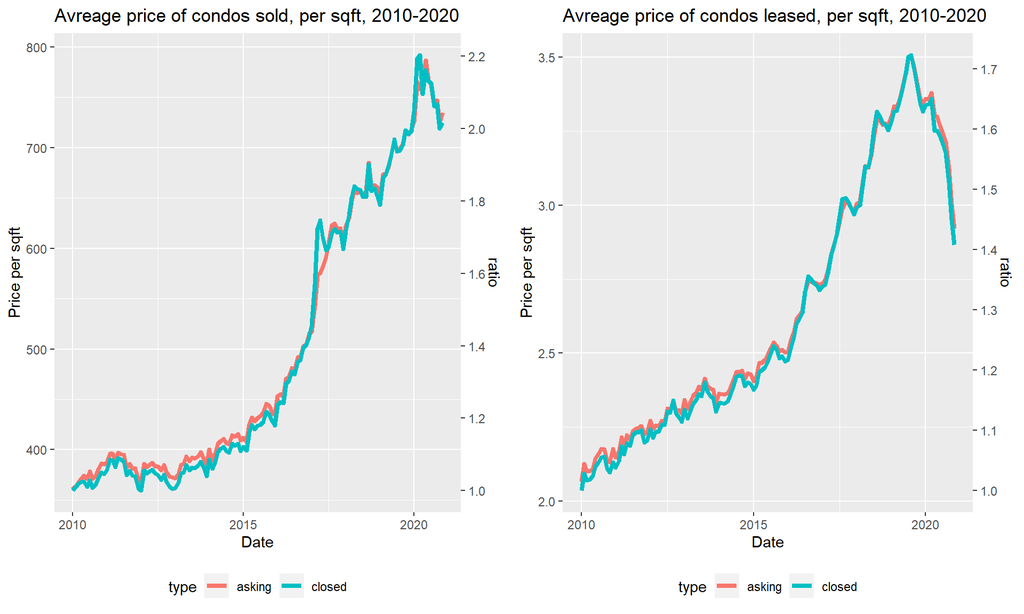

## Time Series: How sizes of condos in Toronto evolved

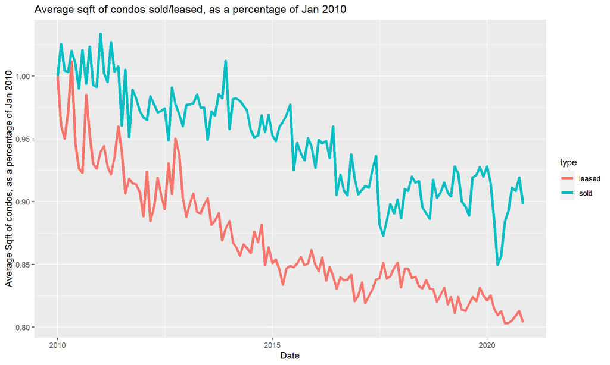